# Assignment 2

Biancamaria Florenzi

r0777934

### Progesterone Receptor Transcriptome and Cistrome in Decidualized Human Endometrial Stroma Cells

The reference literature is available at:

Mazur EC, Vasquez YM, Li X, Kommagani R, Jiang L, Chen R, Lanz RB, Kovanci E, Gibbons WE, DeMayo FJ. Progesterone receptor transcriptome and cistrome in decidualized human endometrial stromal cells. Endocrinology. 2015 Jun;156(6):2239-53. doi: 10.1210/en.2014-1566. Epub 2015 Mar 17. PMID: 25781565; PMCID: PMC4430623.

The Chip-seq data has been downloaded from SRA, where it is available at the following link:

https://www.ncbi.nlm.nih.gov/sra?term=SRP059136

In the experiment, Chromatin-Immunoprecipitation sequencing data have been generated, using Illumina platform, with antibody against PGR (progesterone receptor), FOSL2 (composes AP-1 transcription factor) and no antibody (for control) on human endometrial stroma cells in which in vitro decidualization had been triggered. The study is part of a superstudy, in which differential expression levels have also been investigated with RNA-seq, with the purpose of gaining better insight into the process of decidualization. Decidualization is a complex process fundamental for enstablishing and supporting a pregnancy, of which the ovarian steroid hormone progesterone, that acts through its necluear receptor, is a key player. Nuclear hormone receptors classically bind directly to DNA in promoter regions, regulating the expression or silencing of particular genes (direct targets), or they have protein-protein interactions with other TF that bind to the DNA (indirect regulation).

Note: Endometrium = inner lining of the uterus, where the embryo implants upon conception

I decided to conduct the analysis in parallel with PGR and FOSL2, as I thought this would give me the opportunity to compare the findings and quality of the analysis. I also hope to obtain overlaps between the target genes.

```bash
cd /mnt/storage/$USER/jupyternotebooks/Assignment_2/
```

```bash
vdb-config -s /repository/user/cache-disabled=true
pwd
```

```
/mnt/storage/r0777934/jupyternotebooks/Assignment_2
```

```bash
START=2051516
END=2051518

for i in $(seq $START $END);
do
    fastq-dump 'SRR'"$i"
done
```

```
Read 33367151 spots for SRR2051516
Written 33367151 spots for SRR2051516
2020-12-08T11:47:18 fastq-dump.2.9.6 sys: timeout exhausted while reading file within network system module - mbedtls_ssl_read returned -76 ( NET - Reading information from the socket failed )
2020-12-08T12:27:35 fastq-dump.2.9.6 sys: timeout exhausted while reading file within network system module - mbedtls_ssl_read returned -76 ( NET - Reading information from the socket failed )
2020-12-08T12:32:56 fastq-dump.2.9.6 sys: timeout exhausted while reading file within network system module - mbedtls_ssl_read returned -76 ( NET - Reading information from the socket failed )
Read 28052094 spots for SRR2051517
Written 28052094 spots for SRR2051517
2020-12-08T12:45:28 fastq-dump.2.9.6 sys: timeout exhausted while reading file within network system module - mbedtls_ssl_read returned -76 ( NET - Reading information from the socket failed )
2020-12-08T13:08:26 fastq-dump.2.9.6 sys: connection failed while opening file within cryptographic module - mbedtls_ssl_handshake returned -76 ( NET - Reading information from the socket failed )
2020-12-08T13:08:26 fastq-dump.2.9.6 sys: connection failed while opening file within cryptographic module - ktls_handshake failed while accessing '165.112.9.235' from '10.118.128.21'
2020-12-08T13:08:26 fastq-dump.2.9.6 sys: connection failed while opening file within cryptographic module - Failed to create TLS stream for 'sra-download.ncbi.nlm.nih.gov' (165.112.9.235) from '10.118.128.21'
2020-12-08T13:08:26 fastq-dump.2.9.6 err: connection failed while opening file within cryptographic module - error with https open 'https://sra-download.ncbi.nlm.nih.gov/traces/refseq/NC_000009.11'
Read 33513636 spots for SRR2051518
Written 33513636 spots for SRR2051518
```

## File check and quality control

```bash
wc -l SRR*.fastq
```

```
  133468604 SRR2051516.fastq
  112208376 SRR2051517.fastq
  134054544 SRR2051518.fastq
  379731524 total
```

```bash
echo $((133468604/4)) #33,367,151
echo $((112208376/4)) #28,052,094
echo $((134054544/4)) #33,513,636
```

```
33367151
28052094
33513636
```

```bash
fastqc SRR*.fastq
```

[output not shown]

[output cut: 8 more lines]

[output not shown]

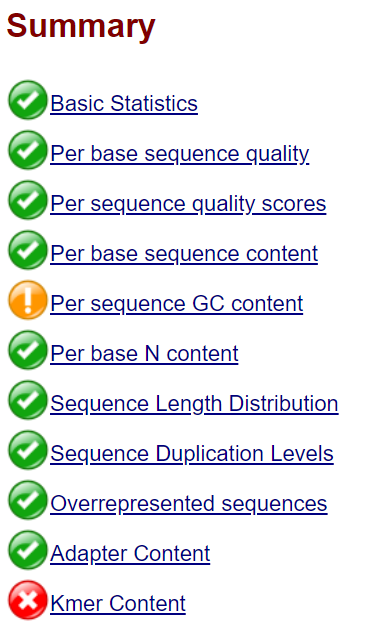

Sequence duplication levels are high for the two files SRR#####17 and SRR#####16 that are the ones that used an antibody, while are normal for the SRR######18 file, which is the input one. This is perfectly fine, because the antibodies are pulling down specific fragments when I use the specific antibodies. The duplication level plot is shown below:

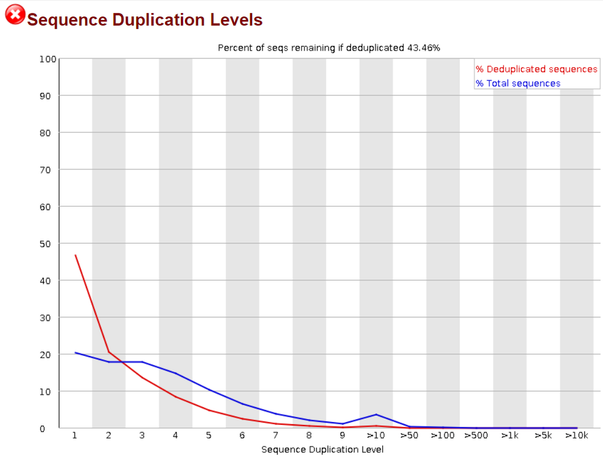

## Alignment with bowtie

I performed the alignment against hg19 with bowtie2

```bash
bowtie2 -x /mnt/storage/data/resources/bowtie2/hg19 SRR2051516.fastq -S PGR.sam
bowtie2 -x /mnt/storage/data/resources/bowtie2/hg19 SRR2051517.fastq -S FOSL2.sam
bowtie2 -x /mnt/storage/data/resources/bowtie2/hg19 SRR2051518.fastq -S input.sam
```

```bash
head -500 input.sam | tail -5
```

```
SRR2051518.410	16	chrY	59354572	1	36M	*	0	0	TCTTCTCGCCCAGGCTTCCAACTCCACCCTCTCCTG	IGIHGIIIIIIGIIIEGGGGGG9GGFIIIIIIIIII	AS:i:0	XS:i:0	XN:i:0	XM:i:0	XO:i:0	XG:i:0	NM:i:0	MD:Z:36	YT:Z:UU
SRR2051518.411	0	chr9	18311	1	36M	*	0	0	GCGGCCTCAGAGGCACGGGGAAATGGAGGGACTGCC	IIIIIIIIIIIIIIIIIIGIIIIIIIIFIIIIIIGI	AS:i:-6	XS:i:-6	XN:i:0	XM:i:1	XO:i:0	XG:i:0	NM:i:1	MD:Z:2A33	YT:Z:UU
SRR2051518.412	16	chr15	102512926	1	36M	*	0	0	CTACTGGGCAGTCCCTCCATTTCCCCGTGCCTCTGA	GHEHHHHHFHHFHHHGGGGDGHD@HHGGGEGGBGGG	AS:i:0	XS:i:0	XN:i:0	XM:i:0	XO:i:0	XG:i:0	NM:i:0	MD:Z:36	YT:Z:UU
SRR2051518.413	16	chr15	102512899	1	36M	*	0	0	TAGTCCCCATACCCCTGTGTCCTGAGGCTACTGGGC	IIIIIIIIIIHIIIIIIIIIIIIIIIIIIIIIIIII	AS:i:0	XS:i:0	XN:i:0	XM:i:0	XO:i:0	XG:i:0	NM:i:0	MD:Z:36	YT:Z:UU
SRR2051518.414	0	chrY	59354459	1	36M	*	0	0	TCAAGGTAGTCCCCATACCCCTGTGTCCTGAGGCTA	IIIIIIIIIIIIIIIIIIIIIIDHHIIIHIIIIIDI	AS:i:0	XS:i:0	XN:i:0	XM:i:0	XO:i:0	XG:i:0	NM:i:0	MD:Z:36	YT:Z:UU
```

```bash
samtools view -S -b PGR.sam > PGR.bam
samtools view -S -b FOSL2.sam > FOSL2.bam
samtools view -S -b input.sam > input.bam
```

```bash
samtools flags UNMAP,SECONDARY
```

```
0x104	260	UNMAP,SECONDARY
```

```bash
samtools sort -O bam -o PGR.sorted.bam PGR.bam
samtools index PGR.sorted.bam
samtools sort -O bam -o FOSL2.sorted.bam FOSL2.bam
samtools index FOSL2.sorted.bam
samtools sort -O bam -o input.sorted.bam input.bam
samtools index input.sorted.bam
```

```
[bam_sort_core] merging from 7 files and 1 in-memory blocks...
[bam_sort_core] merging from 6 files and 1 in-memory blocks...
[bam_sort_core] merging from 7 files and 1 in-memory blocks...
```

```bash
samtools idxstats PGR.sorted.bam
```

```
chr1	249250621	2481516	0
chr2	243199373	2639264	0
chr3	198022430	2119944	0
chr4	191154276	1996375	0
chr5	180915260	1882611	0
chr6	171115067	1872514	0
chr7	159138663	1614049	0
chr8	146364022	1520238	0
chr9	141213431	1284997	0
chr10	135534747	1493192	0
chr11	135006516	1362842	0
chr12	133851895	1453940	0
chr13	115169878	1031364	0
chr14	107349540	919471	0
chr15	102531392	915940	0
chr16	90354753	811087	0
chr17	81195210	861216	0
chr18	78077248	758243	0
chr19	59128983	534352	0
chr20	63025520	592004	0
chr21	48129895	384638	0
chr22	51304566	341270	0
chrX	155270560	1245433	0
chrY	59373566	61010	0
chrM	16571	75678	0
chr1_gl000191_random	106433	1022	0
chr1_gl000192_random	547496	5302	0
chr4_gl000193_random	189789	1744	0
chr4_gl000194_random	191469	1640	0
chr7_gl000195_random	182896	5377	0
chr8_gl000196_random	38914	289	0
chr8_gl000197_random	37175	108	0
chr9_gl000198_random	90085	1127	0
chr9_gl000199_random	169874	40798	0
chr9_gl000200_random	187035	616	0
chr9_gl000201_random	36148	121	0
chr11_gl000202_random	40103	331	0
chr17_gl000203_random	37498	187	0
chr17_gl000204_random	81310	256	0
chr17_gl000205_random	174588	3651	0
```

[output cut: 30 more lines]

```
chrUn_gl000236	41934	209	0
chrUn_gl000237	45867	484	0
chrUn_gl000238	39939	147	0
chrUn_gl000239	33824	399	0
chrUn_gl000240	41933	327	0
chrUn_gl000241	42152	960	0
chrUn_gl000242	43523	227	0
chrUn_gl000243	43341	473	0
chrUn_gl000244	39929	254	0
chrUn_gl000245	36651	435	0
chrUn_gl000246	38154	155	0
chrUn_gl000247	36422	262	0
chrUn_gl000248	39786	220	0
chrUn_gl000249	38502	277	0
*	0	0	2939287
```

I have visualised the HAND2 gene in IGV, showing all three tracks.

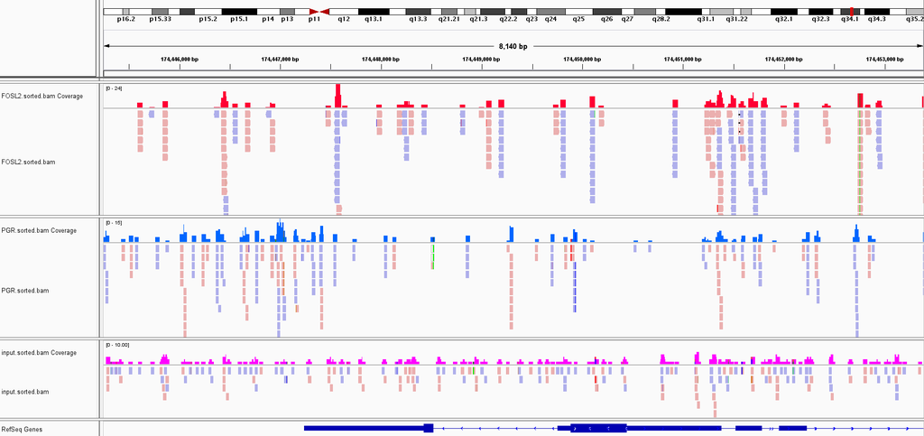

## Genome wide coverage plots

I have created the bigWig files. The human effective genome size is 2864785220.

```bash
bamCoverage -b PGR.sorted.bam --normalizeUsing RPGC --effectiveGenomeSize 2864785220 -o PGR.bw
```

```
normalization: 1x (effective genome size 2864785220)
bamFilesList: ['PGR.sorted.bam']
binLength: 50
numberOfSamples: None
blackListFileName: None
skipZeroOverZero: False
bed_and_bin: False
defaultFragmentLength: read length
numberOfProcessors: 1
verbose: False
region: None
bedFile: None
minMappingQuality: None
ignoreDuplicates: False
chrsToSkip: []
stepSize: 50
center_read: False
samFlag_include: None
samFlag_exclude: None
minFragmentLength: 0
maxFragmentLength: 0
zerosToNans: False
smoothLength: None
save_data: False
out_file_for_raw_data: None
maxPairedFragmentLength: 1000
```

```bash
bamCoverage -b input.sorted.bam --normalizeUsing RPGC --effectiveGenomeSize 2864785220 -o input.bw
bamCoverage -b FOSL2.sorted.bam --normalizeUsing RPGC --effectiveGenomeSize 2864785220 -o FOSL2.bw
```

```
normalization: 1x (effective genome size 2864785220)
bamFilesList: ['input.sorted.bam']
binLength: 50
numberOfSamples: None
blackListFileName: None
skipZeroOverZero: False
bed_and_bin: False
defaultFragmentLength: read length
numberOfProcessors: 1
verbose: False
region: None
bedFile: None
minMappingQuality: None
ignoreDuplicates: False
chrsToSkip: []
stepSize: 50
center_read: False
samFlag_include: None
samFlag_exclude: None
minFragmentLength: 0
maxFragmentLength: 0
zerosToNans: False
smoothLength: None
save_data: False
out_file_for_raw_data: None
maxPairedFragmentLength: 1000
```

```bash
ls *.bw
```

```
FOSL2.bw  input.bw  PGR.bw
```

The HAND2 gene, showing PGR and input, with bw file and coverage as well.

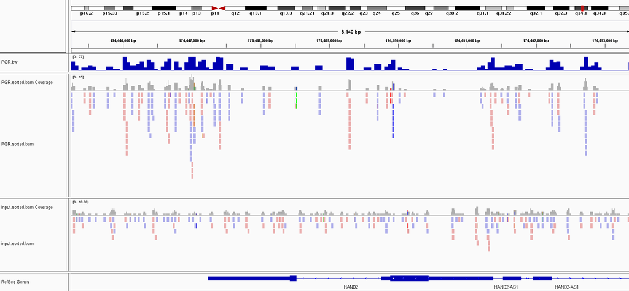

Notice the shift in the peak:

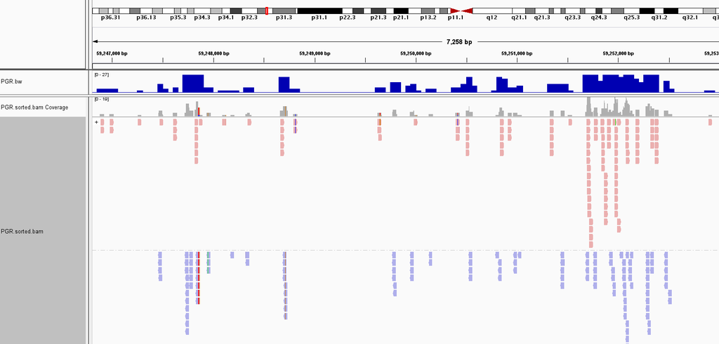

This is normal in ChiP-seq experiments, there is a strand asymmetry with read densities on the forward and reverse strand, centered around the binding site, determined by the technique itself.

## Peak calling with MACS2

```bash
macs2 callpeak -t PGR.sorted.bam -c input.sorted.bam -n PGR -g 2864785220 -q 0.5
```

```
INFO  @ Wed, 09 Dec 2020 15:34:52:
# Command line: callpeak -t PGR.sorted.bam -c input.sorted.bam -n PGR -g 2864785220 -q 0.5
# ARGUMENTS LIST:
# name = PGR
# format = AUTO
# ChIP-seq file = ['PGR.sorted.bam']
# control file = ['input.sorted.bam']
# effective genome size = 2.86e+09
# band width = 300
# model fold = [5, 50]
# qvalue cutoff = 5.00e-01
# The maximum gap between significant sites is assigned as the read length/tag size.
# The minimum length of peaks is assigned as the predicted fragment length "d".
# Larger dataset will be scaled towards smaller dataset.
# Range for calculating regional lambda is: 1000 bps and 10000 bps
# Broad region calling is off
# Paired-End mode is off

INFO  @ Wed, 09 Dec 2020 15:34:52: #1 read tag files...
INFO  @ Wed, 09 Dec 2020 15:34:52: #1 read treatment tags...
INFO  @ Wed, 09 Dec 2020 15:34:52: Detected format is: BAM
INFO  @ Wed, 09 Dec 2020 15:34:52: * Input file is gzipped.
INFO  @ Wed, 09 Dec 2020 15:34:54:  1000000
INFO  @ Wed, 09 Dec 2020 15:34:56:  2000000
INFO  @ Wed, 09 Dec 2020 15:34:58:  3000000
INFO  @ Wed, 09 Dec 2020 15:35:00:  4000000
INFO  @ Wed, 09 Dec 2020 15:35:02:  5000000
INFO  @ Wed, 09 Dec 2020 15:35:04:  6000000
INFO  @ Wed, 09 Dec 2020 15:35:07:  7000000
INFO  @ Wed, 09 Dec 2020 15:35:09:  8000000
INFO  @ Wed, 09 Dec 2020 15:35:11:  9000000
INFO  @ Wed, 09 Dec 2020 15:35:13:  10000000
INFO  @ Wed, 09 Dec 2020 15:35:15:  11000000
INFO  @ Wed, 09 Dec 2020 15:35:17:  12000000
INFO  @ Wed, 09 Dec 2020 15:35:19:  13000000
INFO  @ Wed, 09 Dec 2020 15:35:21:  14000000
INFO  @ Wed, 09 Dec 2020 15:35:23:  15000000
INFO  @ Wed, 09 Dec 2020 15:35:25:  16000000
INFO  @ Wed, 09 Dec 2020 15:35:27:  17000000
INFO  @ Wed, 09 Dec 2020 15:35:29:  18000000
```

[output cut: 62 more lines]

```
INFO  @ Wed, 09 Dec 2020 15:37:12: #1  Redundant rate of control: 0.18
INFO  @ Wed, 09 Dec 2020 15:37:12: #1 finished!
INFO  @ Wed, 09 Dec 2020 15:37:12: #2 Build Peak Model...
INFO  @ Wed, 09 Dec 2020 15:37:12: #2 looking for paired plus/minus strand peaks...
INFO  @ Wed, 09 Dec 2020 15:37:14: #2 number of paired peaks: 48247
INFO  @ Wed, 09 Dec 2020 15:37:14: start model_add_line...
INFO  @ Wed, 09 Dec 2020 15:37:14: start X-correlation...
INFO  @ Wed, 09 Dec 2020 15:37:14: end of X-cor
INFO  @ Wed, 09 Dec 2020 15:37:14: #2 finished!
INFO  @ Wed, 09 Dec 2020 15:37:14: #2 predicted fragment length is 162 bps
INFO  @ Wed, 09 Dec 2020 15:37:14: #2 alternative fragment length(s) may be 162 bps
INFO  @ Wed, 09 Dec 2020 15:37:14: #2.2 Generate R script for model : PGR_model.r
INFO  @ Wed, 09 Dec 2020 15:37:14: #3 Call peaks...
INFO  @ Wed, 09 Dec 2020 15:37:14: #3 Pre-compute pvalue-qvalue table...
INFO  @ Wed, 09 Dec 2020 15:39:03: #3 Call peaks for each chromosome...
```

```bash
macs2 callpeak -t FOSL2.bam -c input.bam -n FOSL2 -g hs -q 0.05
```

```
INFO  @ Thu, 10 Dec 2020 16:42:01:
# Command line: callpeak -t FOSL2.bam -c input.bam -n FOSL2 -g hs -q 0.05
# ARGUMENTS LIST:
# name = FOSL2
# format = AUTO
# ChIP-seq file = ['FOSL2.bam']
# control file = ['input.bam']
# effective genome size = 2.70e+09
# band width = 300
# model fold = [5, 50]
# qvalue cutoff = 5.00e-02
# The maximum gap between significant sites is assigned as the read length/tag size.
# The minimum length of peaks is assigned as the predicted fragment length "d".
# Larger dataset will be scaled towards smaller dataset.
# Range for calculating regional lambda is: 1000 bps and 10000 bps
# Broad region calling is off
# Paired-End mode is off

INFO  @ Thu, 10 Dec 2020 16:42:01: #1 read tag files...
INFO  @ Thu, 10 Dec 2020 16:42:01: #1 read treatment tags...
INFO  @ Thu, 10 Dec 2020 16:42:02: Detected format is: BAM
INFO  @ Thu, 10 Dec 2020 16:42:02: * Input file is gzipped.
INFO  @ Thu, 10 Dec 2020 16:42:04:  1000000
INFO  @ Thu, 10 Dec 2020 16:42:06:  2000000
INFO  @ Thu, 10 Dec 2020 16:42:08:  3000000
INFO  @ Thu, 10 Dec 2020 16:42:10:  4000000
INFO  @ Thu, 10 Dec 2020 16:42:12:  5000000
INFO  @ Thu, 10 Dec 2020 16:42:14:  6000000
INFO  @ Thu, 10 Dec 2020 16:42:16:  7000000
INFO  @ Thu, 10 Dec 2020 16:42:18:  8000000
INFO  @ Thu, 10 Dec 2020 16:42:21:  9000000
INFO  @ Thu, 10 Dec 2020 16:42:23:  10000000
INFO  @ Thu, 10 Dec 2020 16:42:25:  11000000
INFO  @ Thu, 10 Dec 2020 16:42:27:  12000000
INFO  @ Thu, 10 Dec 2020 16:42:30:  13000000
INFO  @ Thu, 10 Dec 2020 16:42:32:  14000000
INFO  @ Thu, 10 Dec 2020 16:42:34:  15000000
INFO  @ Thu, 10 Dec 2020 16:42:36:  16000000
INFO  @ Thu, 10 Dec 2020 16:42:38:  17000000
INFO  @ Thu, 10 Dec 2020 16:42:40:  18000000
```

[output cut: 57 more lines]

```
INFO  @ Thu, 10 Dec 2020 16:44:12: #1  Redundant rate of control: 0.18
INFO  @ Thu, 10 Dec 2020 16:44:12: #1 finished!
INFO  @ Thu, 10 Dec 2020 16:44:12: #2 Build Peak Model...
INFO  @ Thu, 10 Dec 2020 16:44:12: #2 looking for paired plus/minus strand peaks...
INFO  @ Thu, 10 Dec 2020 16:44:14: #2 number of paired peaks: 87518
INFO  @ Thu, 10 Dec 2020 16:44:14: start model_add_line...
INFO  @ Thu, 10 Dec 2020 16:44:14: start X-correlation...
INFO  @ Thu, 10 Dec 2020 16:44:14: end of X-cor
INFO  @ Thu, 10 Dec 2020 16:44:14: #2 finished!
INFO  @ Thu, 10 Dec 2020 16:44:14: #2 predicted fragment length is 155 bps
INFO  @ Thu, 10 Dec 2020 16:44:14: #2 alternative fragment length(s) may be 155 bps
INFO  @ Thu, 10 Dec 2020 16:44:14: #2.2 Generate R script for model : FOSL2_model.r
INFO  @ Thu, 10 Dec 2020 16:44:14: #3 Call peaks...
INFO  @ Thu, 10 Dec 2020 16:44:14: #3 Pre-compute pvalue-qvalue table...
INFO  @ Thu, 10 Dec 2020 16:45:54: #3 Call peaks for each chromosome...
```

```bash
cat PGR_peaks.narrowPeak | wc -l
```

```
106004
```

```bash
cat FOSL2_peaks.narrowPeak | wc -l
```

```
44335
```

```bash
head PGR_peaks.narrowPeak
```

```
chr1	9909	10080	PGR_peak_1	12	.	1.73129	4.05174	1.26872	150
chr1	28583	28745	PGR_peak_2	10	.	3.10163	3.78379	1.05174	46
chr1	30002	30174	PGR_peak_3	19	.	3.59269	4.95940	1.93820	85
chr1	34244	34864	PGR_peak_4	18	.	2.74221	4.82431	1.81544	546
chr1	38621	38959	PGR_peak_5	22	.	4.07208	5.28441	2.20631	46
chr1	42028	42325	PGR_peak_6	28	.	4.26193	6.03892	2.82955	128
chr1	56955	57117	PGR_peak_7	6	.	2.82747	2.92678	0.60643	126
chr1	62883	63045	PGR_peak_8	6	.	2.87961	3.00783	0.67168	42
chr1	65563	65727	PGR_peak_9	5	.	2.79252	2.87296	0.57844	78
chr1	72451	72706	PGR_peak_10	24	.	4.40741	5.53816	2.40142	128
```

At the gene HAND2 there is indeed a peak in PGR:

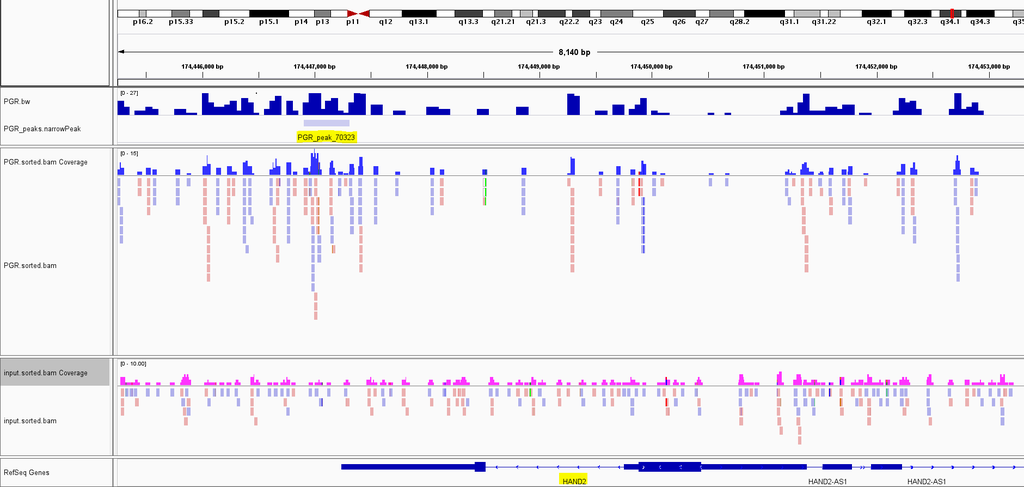

Creating file with the first columns of the narrowPeak file for further motif analysis

```bash
cat PGR_peaks.narrowPeak | cut -f 1-3 > PGR_peaks.bed
```

```bash
cat FOSL2_peaks.narrowPeak | cut -f 1-3 > FOSL2_peaks.bed
```

Note: while making a last-day review of the notebook, I realised I ran the macs2 peak calling with a wrong threshold for PGR. Indeed, it is too high and was not intentional. Time didn't allow for a rerun of the work, which I would have done otherwise. I had noticed before that the number of peaks seemed too high, but I am afraid I didn't give that red flag the attention I should have. Using a high cutoff indeed made the number of peak get larger, and I also suspect that it is the reason why in i-cis Target the PGR motif was not among the top, since the search had not been specific enough.

### Plotting the coverage of the data

```bash
computeMatrix reference-point \
    -S PGR.bw \
    -R PGR_peaks.bed \
    --referencePoint center \
    -a 2000 \
    -b 2000 \
    --binSize 5 \
    -out PGR.tab.gz
```

```bash
plotHeatmap \
    -m PGR.tab.gz \
    -out PGR-peaks5.png \
    --heatmapHeight 15  \
    --refPointLabel peak.center \
    --regionsLabel peaks \
    --plotTitle 'ChIP-seq signal'
```

The plot looks like this:

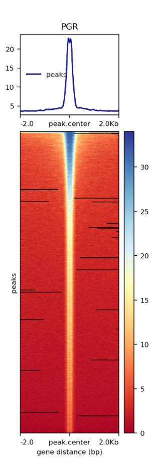

```bash
computeMatrix reference-point \
    -S FOSL2.bw \
    -R FOSL2_peaks.bed \
    --referencePoint center \
    -a 2000 \
    -b 2000 \
    --binSize 5 \
    -out FOSL2.tab.gz
```

```bash
plotHeatmap \
    -m FOSL2.tab.gz \
    -out FOSL2-peaks5.png \
    --heatmapHeight 15  \
    --refPointLabel peak.center \
    --regionsLabel peaks \
    --plotTitle 'ChIP-seq signal'
```

[output not shown]

## De novo motif discovery with RSAT

Used fetch-sequences from Sequence tools in RSAT to get the fasta files of the peaks from the bed file of the peaks and then ran peak-motifs from NGS-Chip-seq. I did this for both FOSL2 and PGR.

PGR result:

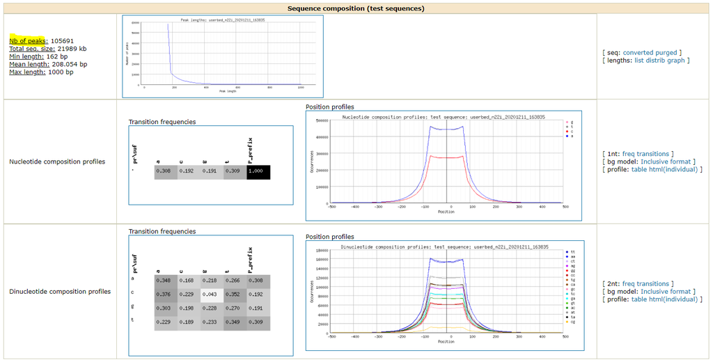

FOSL2 report

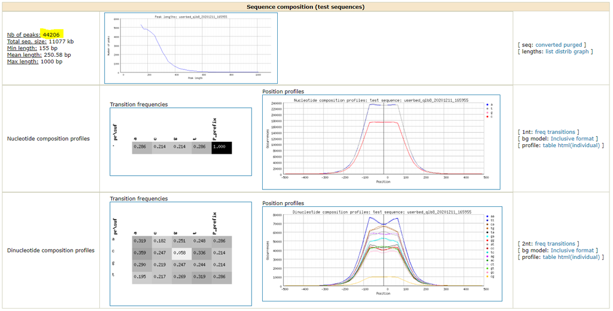

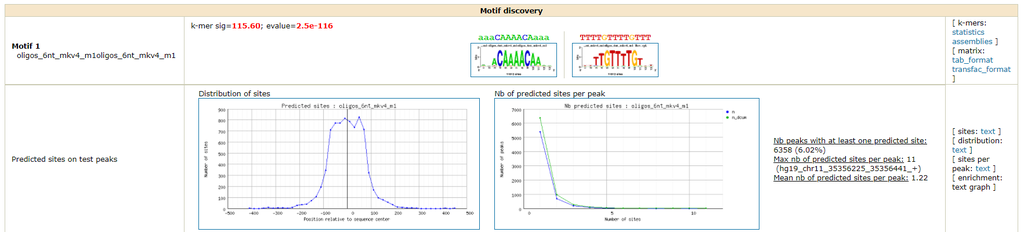

## i-cisTarget for PGR

We test for enrichment of motifs against a database. From Chip-seq narrowpeak file. I ran i-cis target from the narrowPeak file that I have obtained from MACS2. The result shows a list of motifs and possible target genes, and the PGR human is found in position 13, while different versions of it, or similar, are present in the first position of the ranking. Indeed, PGR is also known as NR3C3, and we find NR3C1 and NR3C2.

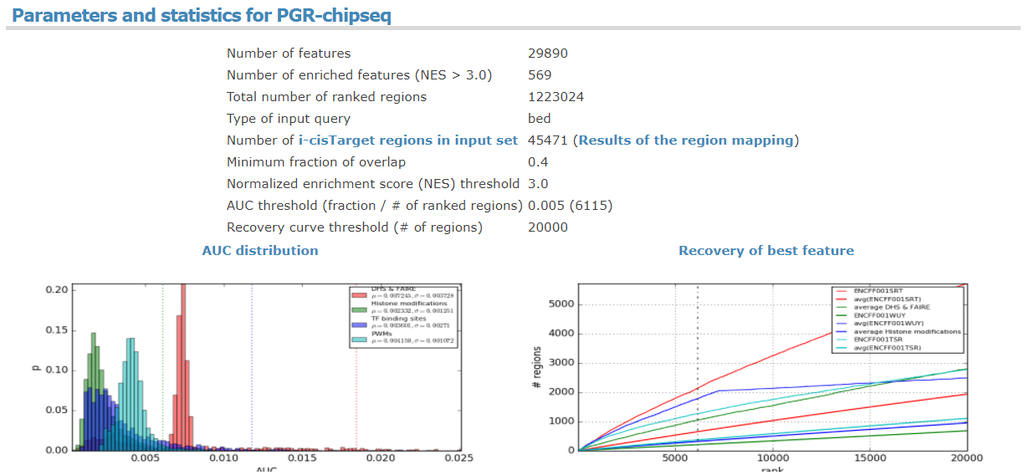

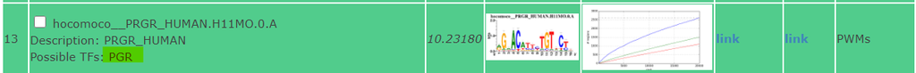

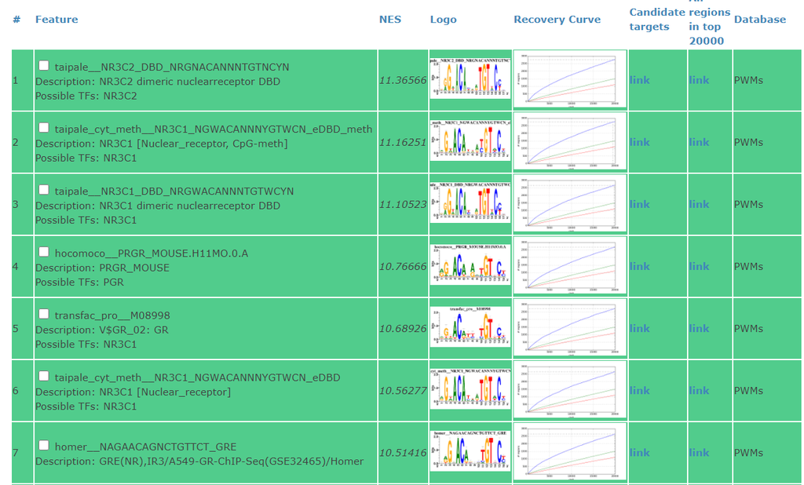

I download the candidate site for the targets of the PGR TF, according to i-cis Target, because I want to connect those sites to genes.

```bash
head hocomoco__PRGR_HUMAN.H11MO.0.A.targets.bed
```

```
track name=hocomoco__PRGR_HUMAN.H11MO.0.A_candidate_targets description="" useScore=1
chr22	39571420	39573235	chr22-reg22536
chr10	70631495	70632408	chr10-reg44353
chr5	59814705	59815808	chr5-reg34614
chr9	137121145	137124015	chr9-reg80029
chr6	126362720	126363734	chr6-reg83046
chr20	4260742	4261742	chr20-reg4255
chr10	4302620	4303705	chr10-reg4200
chr16	86376645	86378115	chr16-reg62614
chr22	18629578	18630578	chr22-reg1586
```

```bash
wc -l hocomoco__PRGR_HUMAN.H11MO.0.A.targets.bed
```

```
2612 hocomoco__PRGR_HUMAN.H11MO.0.A.targets.bed
```

Upload this candidate target sites to GREAT, a preliminary view shows what type of GO terms are connected to the genes and sites that I am querying. I see that some elements are connected to the scope of this study.

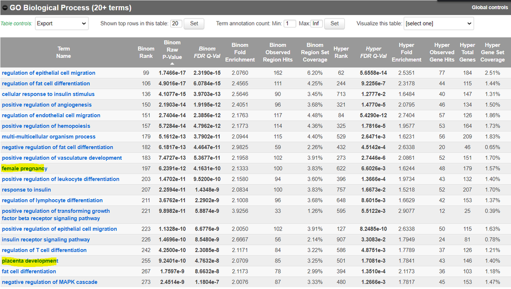

```bash
ls 20201216*.txt
```

```
20201216-public-4.0.4-tJOWmG-hg19-all-gene.txt
```

```bash
head 20201216-public-4.0.4-tJOWmG-hg19-all-gene.txt
```

```
# GREAT version 4.0.4	Species assembly: hg19	Association rule: Basal+extension: 5000 bp upstream, 1000 bp downstream, 1000000 bp max extension, curated regulatory domains included
AAGAB	chr15-reg34474 (+75915)
AASDHPPT	chr11-reg72696 (+910944)
AATK	chr17-reg73401 (+108616)
ABCA1	chr9-reg51602 (-42402), chr9-reg51545 (+21104)
ABCA12	chr2-reg144580 (+282828)
ABCA4	chr1-reg83002 (+84166), chr1-reg82993 (+89683)
ABCA8	chr17-reg59755 (+243282)
ABCB5	chr7-reg15422 (-21034)
ABCC1	chr16-reg15383 (+144744)
```

```bash
cat 20201216-public-4.0.4-tJOWmG-hg19-all-gene.txt | cut -f 1 | grep -v '#' | wc -l
```

```
3063
```

```bash
cat 20201216-public-4.0.4-tJOWmG-hg19-all-gene.txt | cut -f 1 | grep -v '#' > PGR-targets-GREAT.txt
```

```bash
wc -l PGR-targets-GREAT.txt
```

```
3063 PGR-targets-GREAT.txt
```

I ran this PGR targets of GREAT to profiler, to have a better idea what the set of candidate gene is functionally related to.

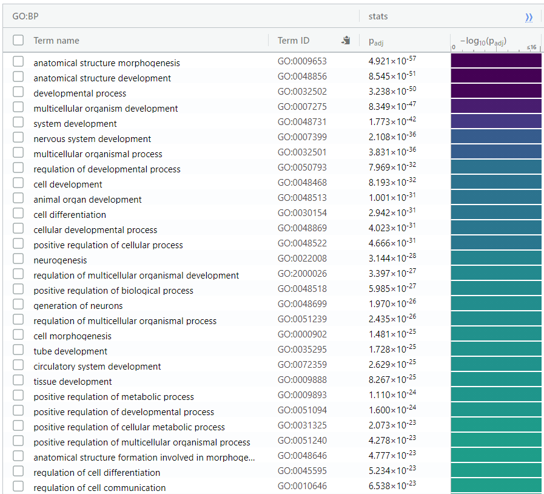

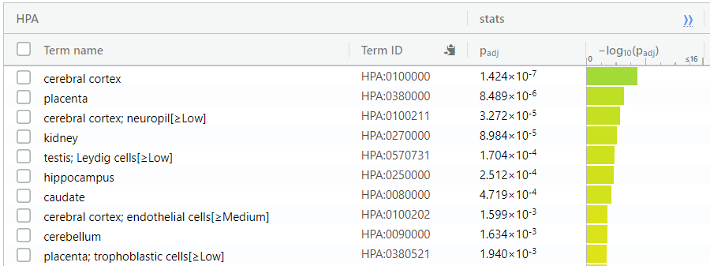

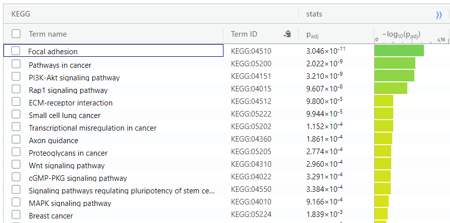

This set of target gene seems very promising. Indeed, terms like structure morphogenesis, differentiation, placenta are coming up a lot; it makes sense, if we think that the thickening of the endometrium during decidualization surely involves cell growth, structure development, cellular differentiation. In other words, these elements are consistent with cells undergoind decidualization.

### Functional association from STRING

The next step is to compare the possible target genes with the functional association of PGR. I have downloaded a list of functionally related proteins to PGR from STRING.

```bash
cat PGR_string_interactions.tsv | cut -f1 | head
```

```
#node1
CDC37
CDC37
CDC37
CDC37
CDC37
CDC37
CDC37
CREBBP
CREBBP
```

```bash
cat PGR_string_interactions.tsv | cut -f 1 | grep -v '#' > PGR-string-top105.txt
```

```bash
cat PGR_string_interactions_more.tsv | cut -f 1 | grep -v '#' > PGR-string-top211.txt
```

```bash
cat PGR_string_interactions_moremore.tsv | cut -f 1 | grep -v '#' > PGR-string-top400.txt
```

```bash
listPGR=`cat PGR-string-top400.txt`
for i in $listPGR; do grep -w $i PGR-targets-GREAT.txt; done > PGR_targets.txt
```

```bash
cat PGR_targets.txt | uniq | wc -l
```

```
19
```

```bash
cat PGR_targets.txt | uniq
```

```
BCAR1
CITED2
CREB1
DNAJB1
DUSP6
ESR1
FKBP4
FKBP5
FOXO3
FYN
HIF1A
HSPA4
HSPA8
JUN
NCOA2
NCOA3
RPS6KA1
STAT3
TBL1X
```

The genes in this file are somehow connected to PGR, according to string, and are also found in the neighbourhood of predicted target sites to the human PGR motif, according to i-cis Target. In notice among these a gene from the FOX genes, that are transcription factors expressed during decidualization to propagate the decidual process itself.

## Comparison with RNA seq data

As mentioned before, the study on ChiP-seq was part of a wider study, in which RNA-seq was performed to identify differentially expressed genes between the control and one in which PGR was silenced. I have downloaded the output file of the edgeR analysis, that contains information over the log change, p-values and FDR, available in Geo Datasets (while the raw is available in SRA).

https://www.ncbi.nlm.nih.gov/sra?term=SRP097736

```bash
ls GSE*
```

```
GSE94036_PR_EPC_vs_EPC.txt
```

```bash
head GSE94036_PR_EPC_vs_EPC.txt
```

```
genes	logFC	logCPM	LR	PValue	FDR
STC1	4.96039969415036	9.26063046263636	814.273328714347	4.25418646197979e-179	5.93586637040041e-175
MYOCD	-4.07544374034192	5.55417747929803	771.365556311742	9.0749954280023e-170	6.3311705603458e-166
NPR3	-4.1943541785152	4.02140608315305	578.869164475394	6.60786074784479e-128	3.07331603382261e-124
VGF	3.8908259823822	4.45424511487031	523.789758719543	6.33921376884036e-116	2.21127624291574e-112
FABP4	4.10872957813706	4.44707586063077	517.509578856902	1.47356217595756e-114	4.11212260822715e-111
CNR1	-5.22333869119666	3.99132016708455	446.411009577333	4.35698519264282e-99	1.01321690654909e-95
CTGF	2.64775591495793	7.40399314005257	425.934582600424	1.24662393712344e-94	2.48487768495477e-91
PARM1	-2.91817585895702	7.39811275155176	422.427917187265	7.22744774855816e-94	1.2605572304454e-90
IGF1	-5.19931404968303	6.3885367958431	377.065665126524	5.41774414931e-84	8.39930934614694e-81
```

```bash
cat GSE94036_PR_EPC_vs_EPC.txt | grep -w -v NA | sort -k2 -gr | cut -f 1,2 > RNA-seq.rnk
```

I created a rank file, in which the genes for which the logFC is higher are on the top. These means that the genes are ordered according to how up-regulated they are. We will use this file to perform a pre-ranked analysis in GSEA. Below, I also have created the gtm file containing the target genes that have been previously selected for PGR. I will need at least 15 genes to use this file as a gene set database, and I have 19 (I had to increase the number of relationship I included from STRING to reach the threshold).

```bash
echo -n "targets","desc",`cat PGR_targets.txt | uniq | tr '\n' ',' ` | tr ',' '\t'
```

```
targets	desc	BCAR1	CITED2	CREB1	DNAJB1	DUSP6	ESR1	FKBP4	FKBP5	FOXO3	FYN	HIF1A	HSPA4	HSPA8	JUN	NCOA2	NCOA3	RPS6KA1	STAT3	TBL1X
```

```bash
echo -n "targets","desc",`cat PGR_targets.txt | uniq | tr '\n' ',' ` | tr ',' '\t' > PGR_targets.gmt
```

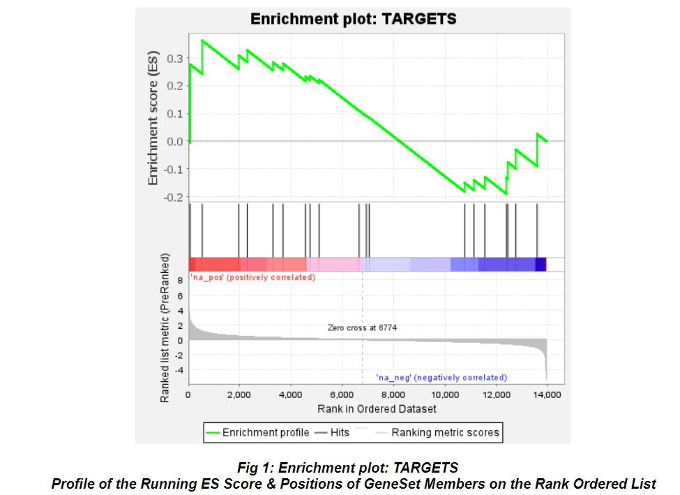

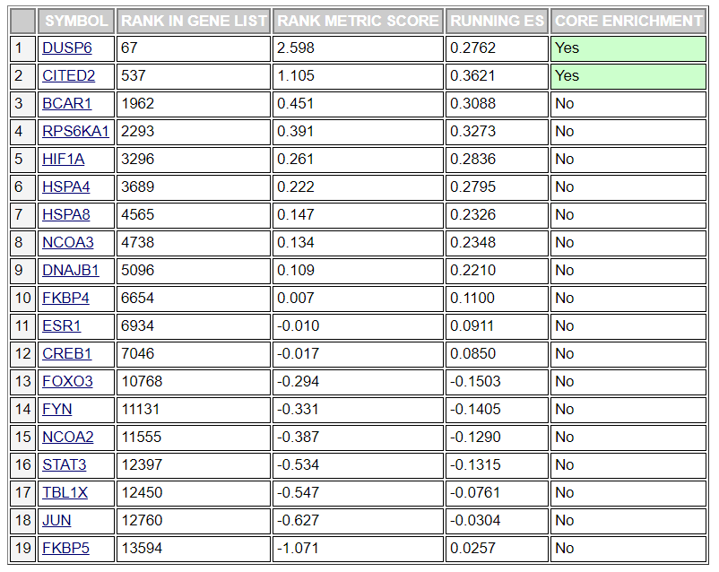

I hoped to obtain more genes in the leading edge, as these would correspond to high confidence PGR targets. My hypothesis is that PGR often has indirect targets, which would not be evident from the differential expression carried out here. I checked the target genes in IGV

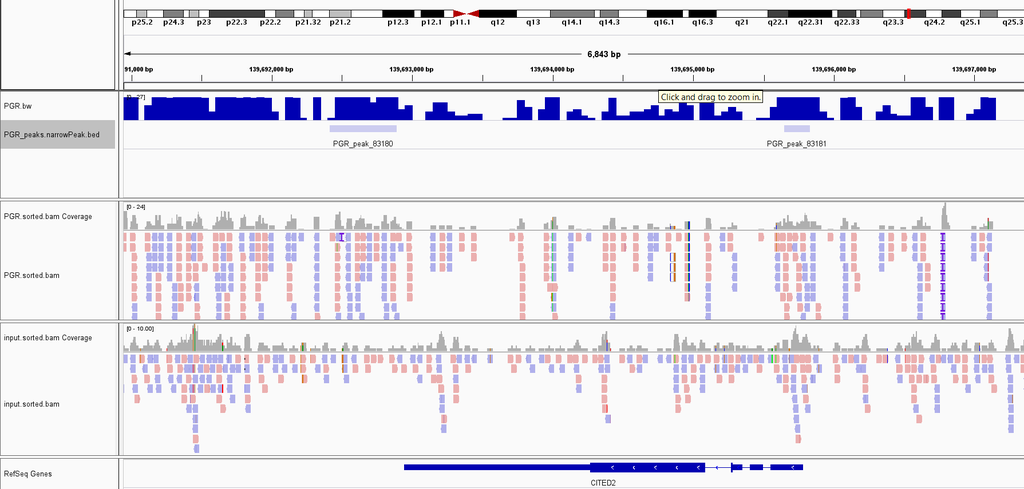

## i-cis target for FOSL2

I ran i-cis target for FOSL2. I download the bed file that contains the ranking.

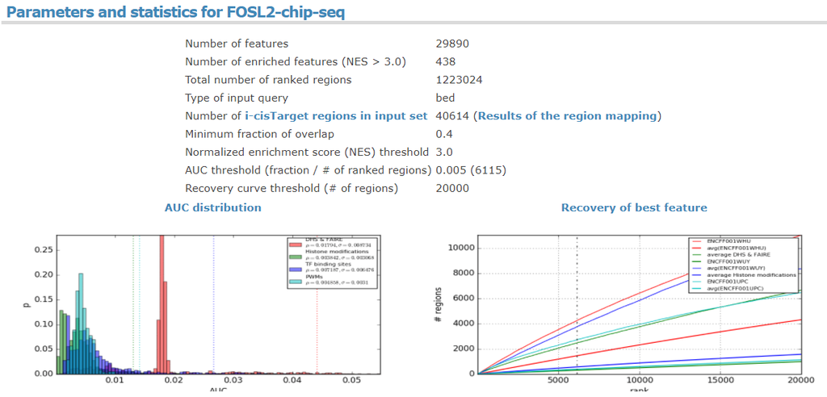

https://gbiomed.kuleuven.be/apps/lcb/i-cisTarget/reports/937070c5b4d4faf27cedf4f6bd82f73e4111c1e0/report.html

The FOSL2 gene is one of the members of the FOS family, which is the first result that I find. FOS proteins in general are as regulators of cell proliferation, differentiation, and transformation.

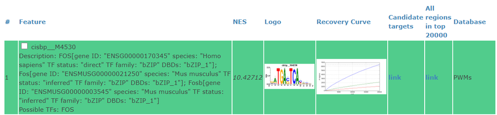

```bash
ls cisbp_*
```

```
cisbp__M4530.targets.bed.txt
```

```bash
head cisbp__M4530.targets.bed.txt
```

```
track name=cisbp__M4530_candidate_targets description="" useScore=1
chr10	4302620	4303705	chr10-reg4200
chr17	75315020	75316408	chr17-reg68742
chr2	205707434	205707875	chr2-reg138299
chr17	75317680	75320255	chr17-reg68745
chr17	31196844	31197794	chr17-reg26626
chr21	17959363	17962631	chr21-reg2484
chr2	173557468	173558218	chr2-reg117077
chr7	29024168	29024988	chr7-reg22106
chr2	43405448	43406427	chr2-reg35212
```

```bash
cat cisbp__M4530.targets.bed.txt | wc -l
```

```
6480
```

#### Link peaks to genes with GREAT

Take the bed file from i-cis target and use GREAT http://great.stanford.edu/public/cgi-bin/showTable.php

http://great.stanford.edu/public/cgi-bin/greatWeb.php

```bash
head 20201215-public-4.0.4-xzCJ7z-hg19-all-gene.txt
```

```
# GREAT version 4.0.4	Species assembly: hg19	Association rule: Basal+extension: 5000 bp upstream, 1000 bp downstream, 50000 bp max extension, curated regulatory domains included
AAK1	chr2-reg53786 (+2037), chr2-reg53738 (+42334)
ABCB10	chr1-reg168524 (-38647)
ABCB6	chr2-reg148996 (+1024)
ABCB8	chr7-reg101622 (+11200)
ABCC1	chr16-reg15148 (-49569)
ABCC12	chr16-reg30115 (+23306)
ABCC2	chr10-reg69616 (-6671)
ABCC3	chr17-reg44800 (+4252), chr17-reg44829 (+27255)
ABCC9	chr12-reg17502 (+22600)
```

```bash
cat 20201215-public-4.0.4-xzCJ7z-hg19-all-gene.txt | cut -f 1 | grep -v '#' | wc -l
```

```
2836
```

```bash
cat 20201215-public-4.0.4-xzCJ7z-hg19-all-gene.txt | cut -f 1 | grep -v '#' | grep JUN
```

```
JUN
```

```bash
cat 20201215-public-4.0.4-xzCJ7z-hg19-all-gene.txt | cut -f 1 | grep -v '#' > FOSL2-targets-GREAT.txt
```

```bash
head FOSL2-targets-GREAT.txt
```

```
AAK1
ABCB10
ABCB6
ABCB8
ABCC1
ABCC12
ABCC2
ABCC3
ABCC9
ABCE1
```

The target genes that we have found in GREAT from the i-cisTarget list of candidate genes are inspected in profiler and I have found:

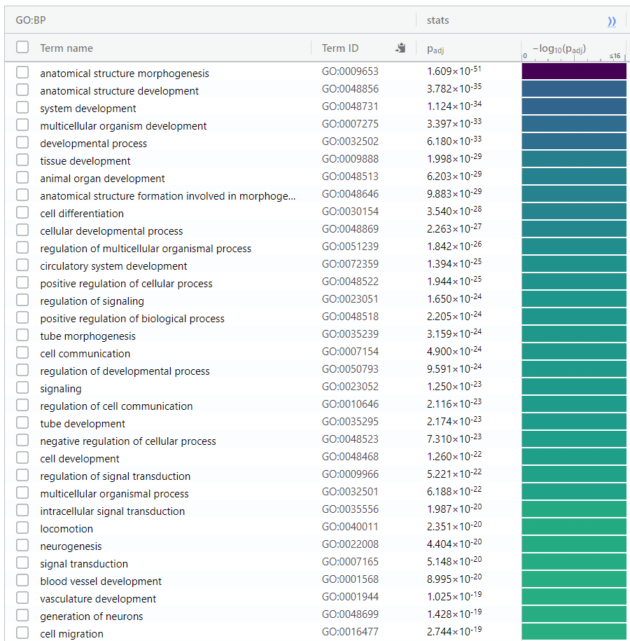

#### Comparison of predicted targets with functional associations to FOSL2 with STRING

```bash
cat FOSL2_string_interactions.tsv | cut -f1 | head
```

```
#node1
ATF4
ATF4
ATF4
ATF4
ATF4
ATF4
ATF4
ATF7
ATF7
```

```bash
cat FOSL2_string_interactions.tsv | cut -f 1 | grep -v '#' > FOSL2-string-top50.txt
```

```bash
wc -l FOSL2_string_interactions_more.tsv
```

```
155 FOSL2_string_interactions_more.tsv
```

```bash
cat FOSL2_string_interactions_more.tsv | cut -f 1 | grep -v '#' > FOSL2-string-top154.txt
```

```bash
wc -l FOSL2-string-top50.txt
```

```
50 FOSL2-string-top50.txt
```

```bash
#list=`cat FOSL2-string-top50.txt`
#for i in $list; do grep -w $i FOSL2-targets-GREAT.txt; done
```

```bash
listFOSL2=`cat FOSL2-string-top154.txt`
for i in $listFOSL2; do grep -w $i FOSL2-targets-GREAT.txt; done > FOSL2_targets.txt
```

```bash
#for i in $list; do grep -w $i FOSL2-targets-GREAT.txt; done > FOSL2_targets.txt
```

```bash
cat FOSL2_targets.txt | uniq | head
```

```
ATF3
ATF4
DDIT3
FOSB
FOSL1
FOSL2
JUN
MAPK8IP1
MAPK9
NFATC2
```

These are likely to be direct targets of FOSL2. This list of genes contains members of the FOS family and the JUN; the association of FOSL2 and JUN has been studied previously, and the two are thought to be interacting as a dimer in decidual stromal cells.

Quick profiler run of these genes shows:

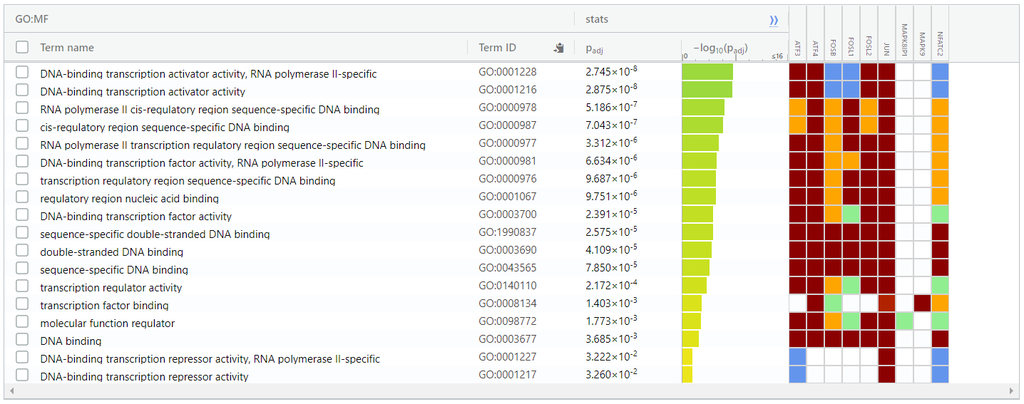

### Conclusion

I expected to find more overlap between the genes that are selected integrating the information from i-cis Target and STRING, between the two analysis. Nevertheless, the target genes found by GREAT linked to the candidate sites are all related to an appropriate set of terms and process, both for PGR and FOSL2; their involvement in the decidualization process has probably not been accurately described during my assignment, but surely shown.